### KSU Data Analytics Capstone Class

### GENBA 894

# Investigation of Data Breaches

### Dataset

I collected a dataset from https://www.privacyrights.org/data-breaches . It was a CSV file with 9 columns and 8,150 records in it. The file was downloaded on 6/4/2018.

The fields contained within the dataset were:

- **"Date Made Public"** (Date) The date the breach was made public. Ranging from 1/10/2005 to 6/1/2018. No null values.
- **"Company"** (String) The Name of the Company that was breached. No null values.
- **"Location"** (String) The location of company. 65 null values.
- **"Type of Breach"** (String) The acronym of the type of breach. No null values
  - 7 types of breaches: Payment Card Fraud, Hacking/Malware, Insider, Physical Loss, Portable Device, Stationary Device, Unintended Disclosure, Unknown
- **"Type of Organization"** (String) the acronym of the organization type. No null values
  - 7 types of organizations: Business Finance/Insurance, Business other, Business Retail/Online, Educational, Government/Military, Healthcare/Medical Insurance, Non-Profit
- **"Total Records"** (Integer) Number of records compromised. 30 null values and 2191 0's which I believe are unknowns or not disclosed.
  - The range was from 0 - 3 billion with an average of 1743514.199 excluding 0's and nulls.
- **"Description of Incident"** (String) a description of what happened. 3 null Values
- **"Information Source"** (String) Where the breach information came from. 54 null values
- **"Source URL"** (String) The URL of the information source. 5410 null values.

## Data Cleaning

These are the steps I took to clean the data before exploration and analysis. For data cleaning I used the Tableau Prep product from Tableau. https://www.tableau.com/products/prep . I chose Tableau Prep because I wanted to experiment with it, understand the product better and because I knew the integration to Tableau, which I was planning to use for my visualization would be simple.

Starting with the Raw datasset I followed these steps:

1. Remove unneeded fields
   - I remove the "Information Source" and "Source URL" Fields.
1. Recover Missing Locations
   - a. I separated out only the records whose location was Null. I felt because none of the company names were null I could look them up manually
   - b. I exported those records, I queried Google for the location of the headquarters of the company listed and added it to the location field
   - c. Using the newly created dataset, I merged the data back into the main dataset. So now I had no more Null values for the location field
1. Split out City, State
   - a. Using a comma as a delimiter, I split the location field in two with the newly created City (left side) as one field, and newly created State (right side) as the other
   - b. I then copied the State Field to a second field called "Location2"
   - c. I renamed any null of missing values to "Unknown"
   - d. For the State field, I changed any Non-US data to "Other"
1. Determine Country
   - a. With Location2, I replaced all US states with "USA"
     - b. Changed any Nulls to "Unknown"
     - c. I selected the remaining records which were not USA or Unknown and exported them to a CSV
       - 1. I mapped the remaining locations to a country using my knowledge of world geography and Google
       - 1. I merged the missing values into the dataset
     - d. I renamed the Location2 field to "Country"
1. Split out Date
   - I split the Date field into Day, Month, Year using the forward slash "/" as the delimiter.
   - I changed the newly created fields from strings to Integers
1. Re-organize Breach and Institutional Type
   - For better visualization displays I re-mapped the shorted acronyms to their full names for the "Breach Type" and "Organizational Type"
1. Business Name Cleaning. The business name field was very 'dirty'. Many of the company names had misspellings or additional information contained in the field so they wouldn't match others even of the same company.
   - a. Remove punctuation
   - b. Trim leading and trailing spaces
   - c. Sort the field ascending
   - d. Replace "Inc" with "" (adding INC to the end was a common problem)
   - e. Export to Excel and manually review names
     - 1. I went through the whole dataset and used my subject knowledge of names of companies and locations to further reduce differences in the same names. Many had misspellings or no spaces between words or the names of partner companies were commonly included. I was able to reduce the unique business names from 6716 to 6060.
1. Replace null values in Total Records
   - a. I imported the dataset back in to Prep and I replaced null values in the field with 0's
   - b. I exported the dataset back out in a format fieldly for Tableau.

This is what the "flow" looks like in Tableau Prep with the steps labeled.

[figure not shown]

```python
from IPython.display import Image
Image("img/Data_Cleaning_Steps_1.png")
```

[figure not shown]

```python
from IPython.display import Image
Image("img/Data_Cleaning_Steps_2.png")
```

This is a close up of step 3. This shows the steps and changes that are made to the data.

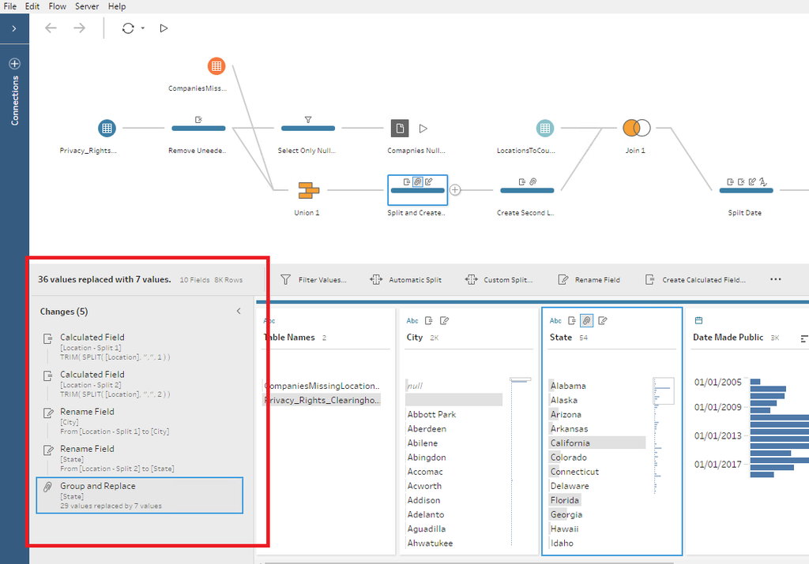

```python
Image("img/city_state_split.png")
```

Another close-up showing the date split from step 5.

[figure not shown]

```python
Image("img/date_split.png")
```

Please find the files used for merging in the "Datasets/For Joins" folder in this repository.

I expect there to be additional cleaning required as the analysis progresses and I begin to build models.